# Outliers in the unpak data

A Strand

2017-04-03

# Outliers

unpakathon provides some functions to help detect outliers for any particular variable.

First load the package

```r
library(unpakathon)
```

then make a long-format dataframe containing the identities of fruitnum outliers. Outliers are defined here as the top and bottom 1% of observations.

```r
tmp = findOutlier(phenolong,"fruitnum",q=0.01,z.score=F)
head(tmp)
```

```
##   plantID    accession treatment  experiment meta.experiment facility
## 1      16 SALK_108266C   control  cofc-first           first COFC-OGH
## 2    1342 SALK_063722C   control  cofc-first           first COFC-OGH
## 3    2721 SALK_033462C   control cofc-second          second COFC-OGH
## 4    2741 SALK_042704C   control cofc-second          second COFC-OGH
## 5    2761 SALK_054680C   control cofc-second          second COFC-OGH
## 6    2771 SALK_059835C   control cofc-second          second COFC-OGH
##   variable value block Gene_idGene direction
## 1 fruitnum   243     1   AT1G23380      high
## 2 fruitnum   203     1   AT1G64390      high
## 3 fruitnum   230     1   AT2G32370      high
## 4 fruitnum   250     1   AT2G39930      high
## 5 fruitnum   274     1   AT3G07120      high
## 6 fruitnum   216     1   AT4G17460      high
```

So the first 6 rows come from experiments cofc-1 and especially cofc-2 (the originals). There are a total of

```r
dim(tmp)[1]
```

```
## [1] 305
```

individual measurements identified

## adjusting for differences among chambers

The ‘z.score’ value in the findOutlier function converts the phenotypes into numbers scaled by the sd in each growth chamber and then mean-subtracted.

```r
tmp = findOutlier(phenolong,"fruitnum",q=0.01,z.score=T)
head(tmp)
```

```
##   treatment experiment facility variable plantID    accession
## 1         A   BC_Expt2   BC-GH1 fruitnum   41731 SALK_047427C
## 2         A   BC_Expt2   BC-GH1 fruitnum   41731 SALK_047427C
## 3         A   BC_Expt2   BC-GH1 fruitnum   43740 SALK_049581C
## 4         A   BC_Expt2   BC-GH1 fruitnum   43740 SALK_049581C
## 5         A   TP1EXPT2 COFC-NGH fruitnum   28589 SALK_023995C
## 6         A   TP1EXPT2 COFC-NGH fruitnum   28785 SALK_075970C
##   meta.experiment    value block Gene_idGene direction
## 1               2 7.845930     2   AT5G41080      high
## 2               2 7.845930     2   AT5G41080      high
## 3               2 3.704128     1   AT1G35540      high
## 4               2 3.704128     1   AT1G35540      high
## 5               2 4.413488     1   AT3G30465      high
## 6               2 4.627601     1   AT3G16650      high
```

In this case there are a lot of experiment 2 treatment A outliers that are appearing. There are a total of

```r
dim(tmp)[1]
```

```
## [1] 308
```

individual measurements identified by this technique (this should not really have changed much because the data are the same as above and we are using quantiles).

## Status of outliers and database.

I’m planning on taking all the outlier information that April sent to me and do one hand-edit of the current database. At this point, I think that will take a day, but I’d like to wait until I have all the experiment 2 data

The main thing that I note from the main unpak experiments plotted below is that there are almost no really weird outliers. Visual inspection of the raw data suggests that there are about 30 values that are ridiculous; For the rest, I’d be hard pressed to rule them actual problem data points. So that’s about 30 out of 313923 data points or an error rate of about 1 per 10,000 phenotypic measurements. That’s pretty good.

## plotting the outliers with the rest of the data for a trait/experiment combination

The following million figures are all distributions of data so far with the findOutlier function and a cutoff of 0.1% point highlighted.

### One more thing:

The number by each point is the plantID from the builtin phenolong and phenowide datasets. To look at a particular plantID, you can say (plantID 21935 has a –too– extreme fruitnum):

```r
phenolong%>%filter(plantID=="21935")
```

```
##    plantID    accession treatment experiment meta.experiment facility
## 1    21935 SALK_049229C   control        1a3               1 COFC-GC1
## 2    21935 SALK_049229C   control        1a3               1 COFC-GC1
## 3    21935 SALK_049229C   control        1a3               1 COFC-GC1
## 4    21935 SALK_049229C   control        1a3               1 COFC-GC1
## 5    21935 SALK_049229C   control        1a3               1 COFC-GC1
## 6    21935 SALK_049229C   control        1a3               1 COFC-GC1
## 7    21935 SALK_049229C   control        1a3               1 COFC-GC1
## 8    21935 SALK_049229C   control        1a3               1 COFC-GC1
## 9    21935 SALK_049229C   control        1a3               1 COFC-GC1
## 10   21935 SALK_049229C   control        1a3               1 COFC-GC1
## 11   21935 SALK_049229C   control        1a3               1 COFC-GC1
## 12   21935 SALK_049229C   control        1a3               1 COFC-GC1
## 13   21935 SALK_049229C   control        1a3               1 COFC-GC1
## 14   21935 SALK_049229C   control        1a3               1 COFC-GC1
```

[output cut: 17 more lines]

to get the long form, or

```r
phenowide%>%filter(plantID=="21935")
```

```
##   plantID    accession treatment experiment meta.experiment facility block
## 1   21935 SALK_049229C   control        1a3               1 COFC-GC1     1
##   aborted.fruits alive.at.harvest avg.fruit.length basal.branch
## 1             12              NaN              NaN            2
##   basalfruit.length biomass branch.basalbranch days.to.bolt days.to.flw
## 1                14     NaN                  2           28         NaN
##   diameter.at.bolt FruitLength1 FruitLength2 FruitLength3 FruitLength4
## 1             45.2          NaN          NaN          NaN          NaN
##   FruitLength5 FruitLength6 FruitLength7 FruitLength8 fruitnum germ.days
## 1          NaN          NaN          NaN          NaN      765       NaN
##   germinants.14d germinants.31d germinants.41d germinants.7d germinated
## 1              3            NaN            NaN             3        NaN
##   inflorescence.height leaf.number mainbranch max.silique midfruit.length
## 1                 34.3         NaN          1         NaN            13.5
##   placeholder seeds.sown ttl.maininfl.branch upperfruit.length Gene_idGene
## 1         NaN          3                   3              10.5   AT1G43890
```

to get the wide form.

A dataframe with just these outliers is available in the builtin R dataframe ‘outliers’ It’s also in the ‘dataclean’ subdirectory of the unpackathon intall on your computer (look in the R library hierarchy). You could look at that dataframe like this:

```r
head(outliers)
```

```
##   treatment experiment facility variable plantID    accession
## 1   control        1a1 COFC-GC1 fruitnum    8999      CS22618
## 2   control        1a1 COFC-GC1 fruitnum    9933 SALK_076067C
## 3   control        1a1 COFC-GC2 fruitnum    9661 SALK_049506C
## 4   control        1a2 COFC-GC1 fruitnum   11883 SALK_058070C
## 5   control        1a3 COFC-GC1 fruitnum   21935 SALK_049229C
## 6   control       3pt2 COFC-GC2 fruitnum   20099      CS22596
##   meta.experiment     value block Gene_idGene direction
## 1               1  6.206960     1                  high
## 2               1  8.869363     1   AT1G66070      high
## 3               1  6.331972     1   AT5G10730      high
## 4               1  6.042439     1   AT5G61730      high
## 5               1 13.307814     1   AT1G43890      high
## 6               3  4.898166     1                  high
```

### ok here we go

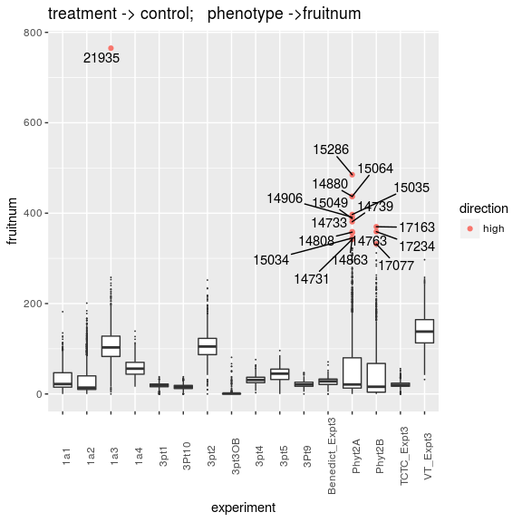

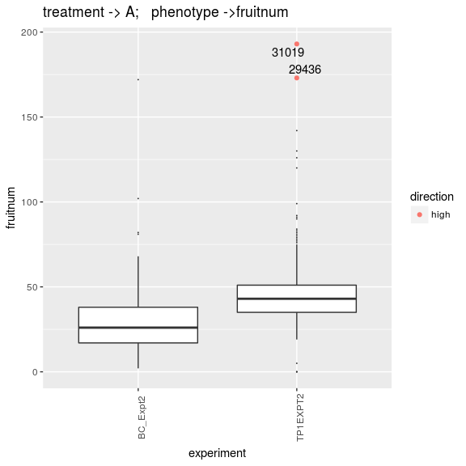

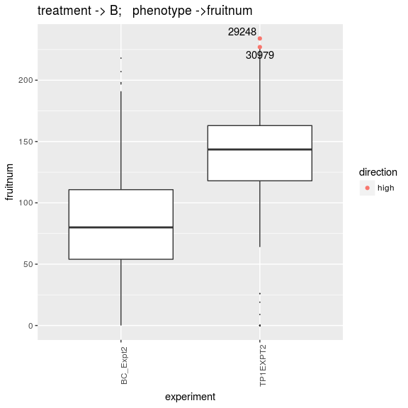

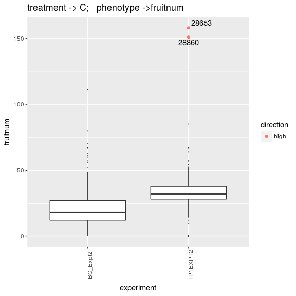

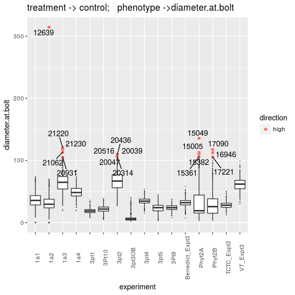

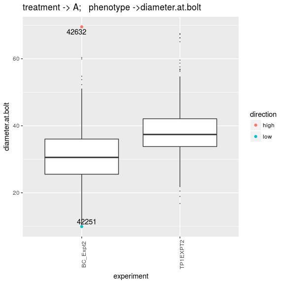

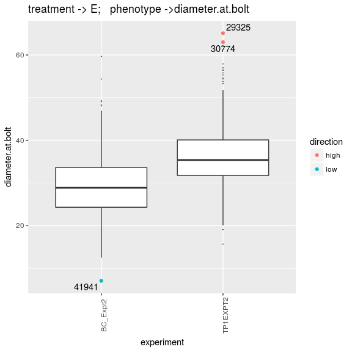

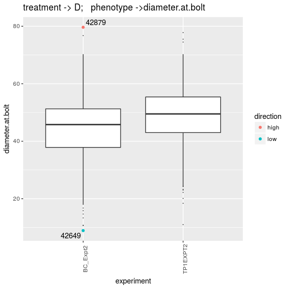

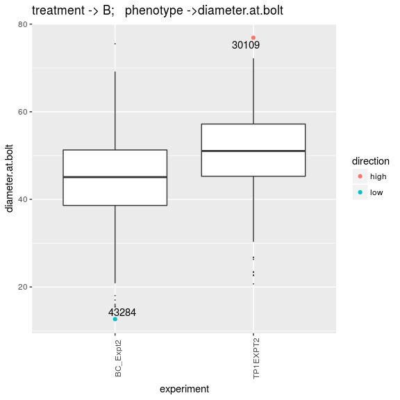

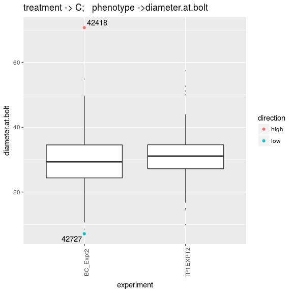

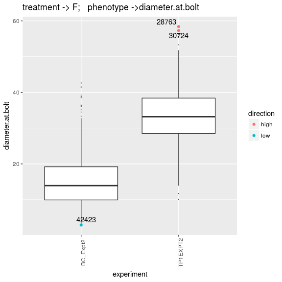

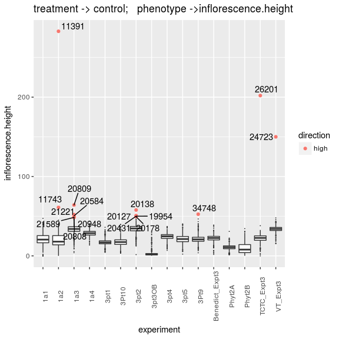

[25 more figures not shown]